# Лабораторная работа № 1

Установка и конфигурация операционной системы на виртуальную машину

Шулуужук А. В.

Российский университет дружбы народов, Москва, Россия

16 февраль 2024

## Цели и задачи

Целью данной работы является приобретение практических навыков установки операционной системы на виртуальную машину, настройки минимально необходимых для дальнейшей работы сервисов.

# Выполнение лабораторной работы

## Создание виртуальной машины

Создаем виртуальную машину:

[figure not shown]

Создание виртуальной машины, путь к iso-образу

Указываем размер основной памяти виртуальной машины – 4096 МБ и число процессоров - 2

[figure not shown]

Установка размера памяти и числа процессоров

Задаем размер виртуального жесткого диска – 30 ГБ

[figure not shown]

Установка размера жесткого диска

Создали виртуальную машину и запускаем образ ОС

[figure not shown]

Созданная виртуальная машина

## Запуск виртуальной машины и образа диска домашней гостевой ОС

В качестве языка интерфейса выбираем английский язык

[figure not shown]

Выбор языка интерфейса

Включим сетевое соединение и в качестве имени узла укажем user.localdomain, где вместо user указываем имя пользователя

[figure not shown]

Установка сети и имени узла

Установим пароль для root, задаем локального пользователя с правами администратора и пароль для него

[figure not shown]

Установка пароля для root

Начинаем установку ОС. Перезагружаем виртуальную машину. Подключаем образ диска дополнений гостевой ОС

[figure not shown]

Подключение образа диска дополнений гостевой ОС

## Домашнее задание

В терминале выполняем команду dmesg и используем его для поиска dmegs | less

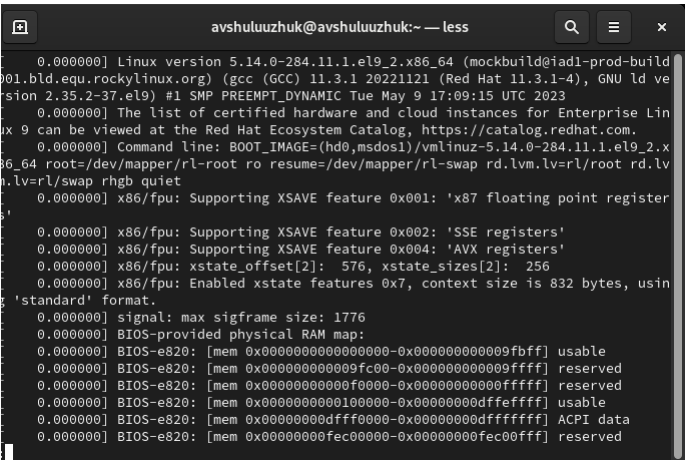

Выполнение команды dmegs | less

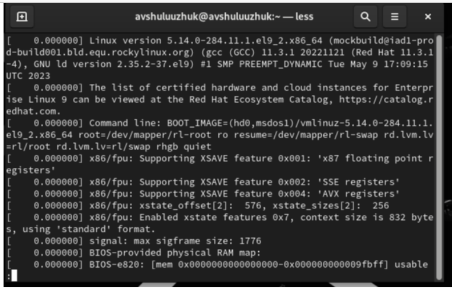

Выполнение команды dmegs | less

Узнаем версию ядра Linux. Команда dmesg | grep -i “linux version”

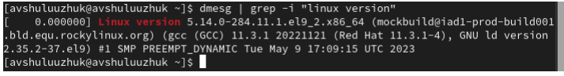

Команда dmesg | grep -i “linux version”

Частота процессора. Команда dmesg | grep -i “MHz

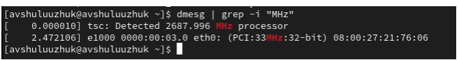

Команда dmesg | grep -i “MHz”

Модель процессора. Команда dmesg | grep -i “CPU0”

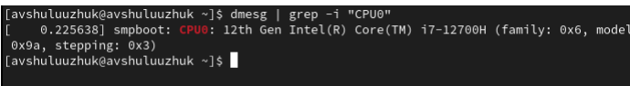

Команда dmesg | grep -i “CPU0”

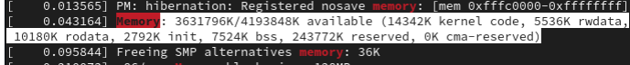

Команда dmesg | grep -i “memory”

Тип обнаруженного гипервизора - KVM. Команда dmesg | grep -i “hypervisor detected”

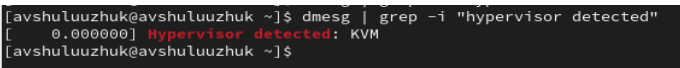

Команда dmesg | grep -i “hypervisor detected”

Тип файловой системы корневого раздела – xfs. Используем команду df -Th

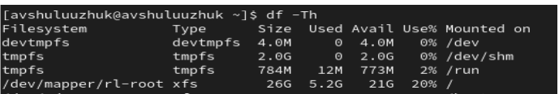

Команда df -Th

Последовательность монтирования файловых систем Для этого используем команду dmesg | grep -i “mount”

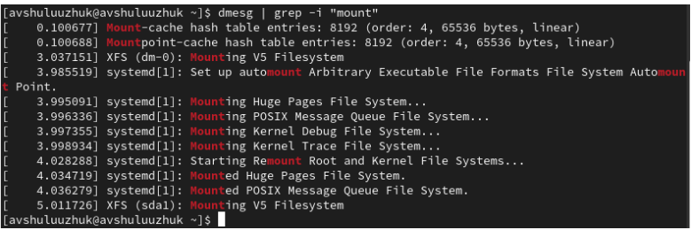

Команда dmesg | grep -i “mount”

## Выводы

В ходе выполнения лабораторной работы были приобретены практические навыки установки операционной системы на виртуальную машину и настройка минимально необходимых для дальнейшей работы сервисов. Было выполнено дополнительное задание, где в процессе мы узнавали требуемую информацию